# Advanced Tutorial

Jakub Wiśniewski

# 1 Model, explanation & bias

In this tutorial you will learn how to tackle bias using the bias mitigation techniques supported by `fairmodels`. As always we will start from the data.

```r
library(fairmodels)

data("adult")
head(adult)
```

|  | salary | age | workclass | fnlwgt | education | education_num | marital_status | occupation | relationship | race | sex | capital_gain | capital_loss | hours_per_week | native_country |
| --- | --- | --- | --- | --- | --- | --- | --- | --- | --- | --- | --- | --- | --- | --- | --- |
| 1 | <=50K | 39 | State-gov | 77516 | Bachelors | 13 | Never-married | Adm-clerical | Not-in-family | White | Male | 2174 | 0 | 40 | United-States |
| 2 | <=50K | 50 | Self-emp-not-inc | 83311 | Bachelors | 13 | Married-civ-spouse | Exec-managerial | Husband | White | Male | 0 | 0 | 13 | United-States |
| 3 | <=50K | 38 | Private | 215646 | HS-grad | 9 | Divorced | Handlers-cleaners | Not-in-family | White | Male | 0 | 0 | 40 | United-States |
| 4 | <=50K | 53 | Private | 234721 | 11th | 7 | Married-civ-spouse | Handlers-cleaners | Husband | Black | Male | 0 | 0 | 40 | United-States |
| 5 | <=50K | 28 | Private | 338409 | Bachelors | 13 | Married-civ-spouse | Prof-specialty | Wife | Black | Female | 0 | 0 | 40 | Cuba |
| 6 | <=50K | 37 | Private | 284582 | Masters | 14 | Married-civ-spouse | Exec-managerial | Wife | White | Female | 0 | 0 | 40 | United-States |

```r
# for this vignette data will be truncated
```

We will use adult data to predict whether certain person has yearly salary exceeding 50 000 or not. Our protected variable will be sex. For this tutorial we will be using `gbm` and of course we will explain it with `DALEX` (Biecek (2018)).

```r
library(gbm)
library(DALEX)

adult$salary   <- as.numeric(adult$salary) -1 # 0 if bad and 1 if good risk
protected     <- adult$sex
adult <- adult[colnames(adult) != "sex"] # sex not specified

# making model
set.seed(1)
gbm_model <-gbm(salary ~. , data = adult, distribution = "bernoulli")

# making explainer
gbm_explainer <- explain(gbm_model,
                         data = adult[,-1],
                         y = adult$salary,
                         colorize = FALSE)
```

```
#> Preparation of a new explainer is initiated
#>   -> model label       :  gbm  (  default  )
#>   -> data              :  32561  rows  13  cols
#>   -> target variable   :  32561  values
#>   -> predict function  :  yhat.gbm  will be used (  default  )
#>   -> predicted values  :  No value for predict function target column. (  default  )
#>   -> model_info        :  package gbm , ver. 2.2.2 , task classification (  default  )
#>   -> predicted values  :  numerical, min =  0.0101498 , mean =  0.2409542 , max =  0.9864558
#>   -> residual function :  difference between y and yhat (  default  )
#>   -> residuals         :  numerical, min =  -0.9790795 , mean =  -0.0001445991 , max =  0.9864904
#>   A new explainer has been created!
```

```r
model_performance(gbm_explainer)
```

```
#> Measures for:  classification
#> recall     : 0.5353909
#> precision  : 0.7999238
#> f1         : 0.6414547
#> accuracy   : 0.8558705
#> auc        : 0.9093643
#>
#> Residuals:
#>          0%         10%         20%         30%         40%         50%
#> -0.97907954 -0.31512711 -0.20921106 -0.12255213 -0.06480941 -0.04122486
#>         60%         70%         80%         90%        100%
#> -0.02832005 -0.01740186  0.13344943  0.53676046  0.98649038
```

Our model has around 86% accuracy. And how about bias? Sex is our protected variable and we should suspect that men will be more frequently assigned better annual income.

```r
fobject <- fairness_check(gbm_explainer,
                          protected  = protected,
                          privileged = "Male",
                          colorize = FALSE)
```

```
#> Creating fairness classification object
#> -> Privileged subgroup       : character ( Ok  )
#> -> Protected variable        : factor ( Ok  )
#> -> Cutoff values for explainers  : 0.5 ( for all subgroups )
#> -> Fairness objects      : 0 objects
#> -> Checking explainers       : 1 in total (  compatible  )
#> -> Metric calculation        : 13/13 metrics calculated for all models
#>  Fairness object created succesfully
```

```r
print(fobject, colorize = FALSE)
```

```
#>
#> Fairness check for models: gbm
#>
#> gbm passes 2/5 metrics
#> Total loss :  2.028729
```

Our model passes only few metrics, how big is the bias?

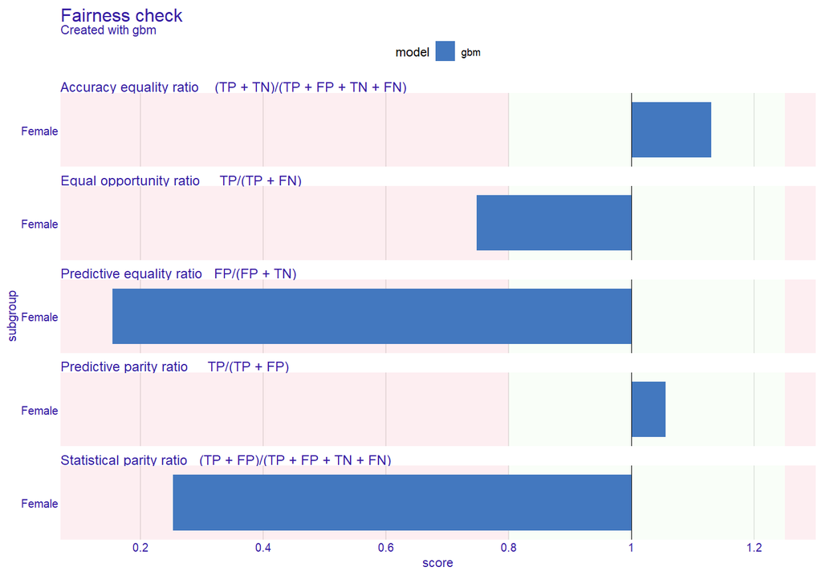

```r
plot(fobject)
```

# 2 Bias mitigation strategies

## 2.1 Pre-processing techniques

Pre-processing techniques focus on changing data **before** model is trained. This reduces bias in data.

### 2.1.1 Distribution changing

Firs technique you will learn about is `disparate_impact_remover` (Feldman et al. (2015)). It is somehow limited as it works on ordinal, numeric data. This technique returns “fixed” data frame. Through parameter `lambda` we can manipulate with how much the distribution will be fixed. `lambda = 1` (default) will return data with identical distributions for all levels of protected variable whereas `lambda = 0` will barely change anything. We will transform a few features.

```r
data_fixed <- disparate_impact_remover(data = adult, protected = protected,
                            features_to_transform = c("age", "hours_per_week",
                                                      "capital_loss",
                                                      "capital_gain"))

set.seed(1)
gbm_model     <- gbm(salary ~. , data = data_fixed, distribution = "bernoulli")
gbm_explainer_dir <- explain(gbm_model,
                             data = data_fixed[,-1],
                             y = adult$salary,
                             label = "gbm_dir",
                             verbose = FALSE)
```

Now we will compare old explainer and new one.

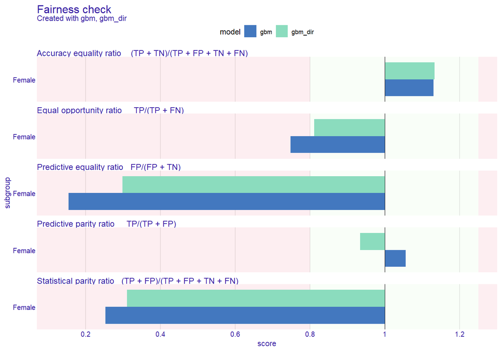

```r
fobject <- fairness_check(gbm_explainer, gbm_explainer_dir,
                          protected = protected,
                          privileged = "Male",
                          verbose = FALSE)
plot(fobject)
```

As we can see bias has diminished. But it is not on acceptable level for us. Let’s try something else. As for now we will add explainers to existing `fairness_object` to compare methods among themselves.

### 2.1.2 Reweighting

Reweighting (Faisal Kamiran and Calders (2011)) is straightforward bias mitigation technique. It produces weights based on data to pass them to model so it can learn what to be careful about. As there can be multiple subgroups weights will come in form of vector.

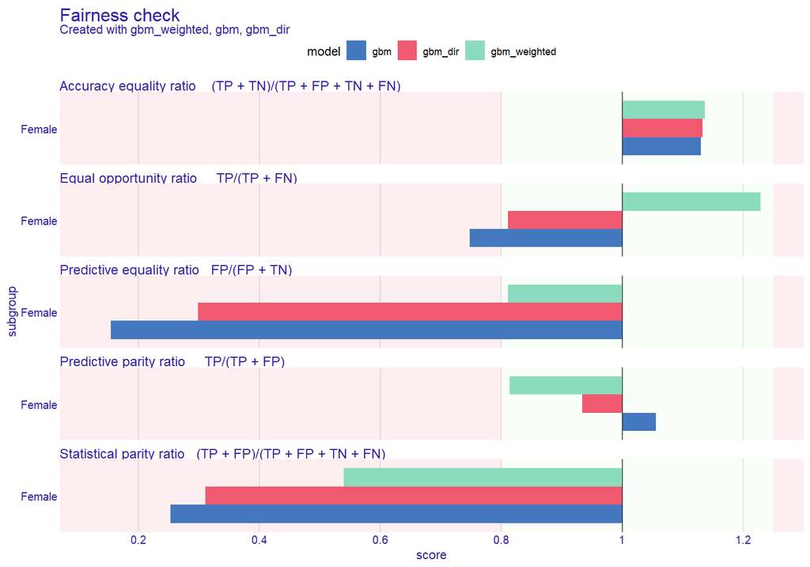

```r
weights <- reweight(protected = protected, y = adult$salary)

set.seed(1)
gbm_model     <- gbm(salary ~. ,
                     data = adult,
                     weights = weights,
                     distribution = "bernoulli")

gbm_explainer_w <- explain(gbm_model,
                           data = adult[,-1],
                           y = adult$salary,
                           label = "gbm_weighted",
                           verbose = FALSE)

fobject <- fairness_check(fobject, gbm_explainer_w, verbose = FALSE)

plot(fobject)
```

Our metric of interest (`Statistical parity ratio`) has been diminished but not enough. Other metrics are within boundaries, so `weighted` passes 4/5 metrics. There are some tradeoffs visible, some metrics increased their scores. It is not something uncommon. To lower the statistical parity the model must classify some unfavorable cases from unprivileged subgroup as favorable and the opposite for privileged subgroup. Similar outcome will be visible in the next method

### 2.1.3 Resampling

This method derives from reweighting the data but instead of weights it chooses observations from data the outcome of metrics (Faisal Kamiran and Calders (2011)). There is 2 types of resampling:  
1. **uniform** - takes random observation from particular subgroup (in particular case - y == 1 or y == 0)  
2. **preferential** - takes/omits observations either close to cutoff or as far from cutoff as possible. It needs probabilities (`probs`)

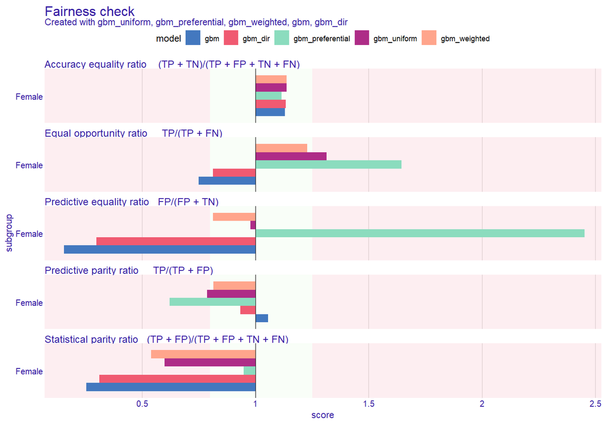

```r
# to obtain probs we will use simple linear regression
probs <- glm(salary ~., data = adult, family = binomial())$fitted.values

uniform_indexes      <- resample(protected = protected,
                                 y = adult$salary)
preferential_indexes <- resample(protected = protected,
                                 y = adult$salary,
                                 type = "preferential",
                                 probs = probs)

set.seed(1)
gbm_model     <- gbm(salary ~. ,
                     data = adult[uniform_indexes,],
                     distribution = "bernoulli")

gbm_explainer_u <- explain(gbm_model,
                           data = adult[,-1],
                           y = adult$salary,
                           label = "gbm_uniform",
                           verbose = FALSE)

set.seed(1)
gbm_model     <- gbm(salary ~. ,
                     data = adult[preferential_indexes,],
                     distribution = "bernoulli")

gbm_explainer_p <- explain(gbm_model,
                           data = adult[,-1],
                           y = adult$salary,
                           label = "gbm_preferential",
                           verbose = FALSE)

fobject <- fairness_check(fobject, gbm_explainer_u, gbm_explainer_p,
                          verbose = FALSE)
plot(fobject)
```

As we can see `preferential` sampling is best at mitigating `Statistical parity ratio`. As byproduct it also affects other metrics significantly.

## 2.2 Post-processing techniques

Post-processing techniques focus on changing the output of model after model is generated

### 2.2.1 ROC pivot

ROC stands for Reject Option based Classification (F. Kamiran, Karim, and Zhang (2012)) and pivot for the behavior of `probs`/`y_hat` as it pivots around the cutoff when it is in close zone. Close zone is defined by the `theta` parameter equal to 0.1 by default. In simple words depending on whether subgroup is privileged or not certain observations will change their probabilities to the opposite (but in equal distance) side of cutoff. For example if observation is unprivileged and unfavorable with probability 0.45 (assuming the `cutoff = 0.5`) probability will change it’s value to 0.55.

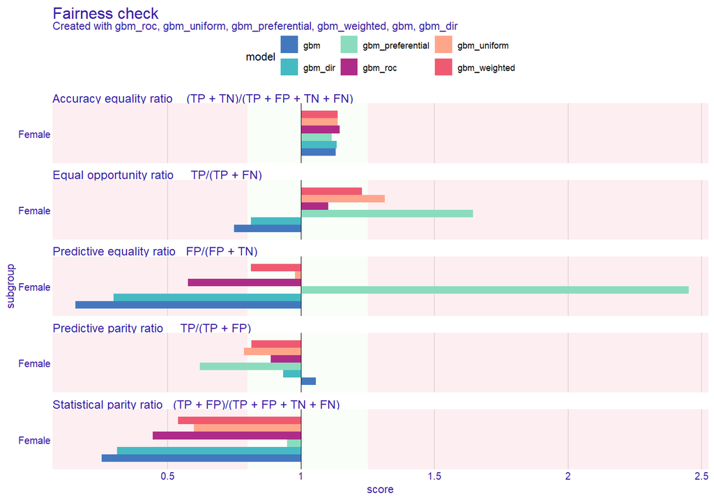

```r
# we will need normal explainer
set.seed(1)
gbm_model <-gbm(salary ~. , data = adult, distribution = "bernoulli")
gbm_explainer <- explain(gbm_model,
                         data = adult[,-1],
                         y = adult$salary,
                         verbose = FALSE)

gbm_explainer_r <- roc_pivot(gbm_explainer,
                             protected = protected,
                             privileged = "Male")


fobject <- fairness_check(fobject, gbm_explainer_r,
                          label = "gbm_roc",  # label as vector for explainers
                          verbose = FALSE)

plot(fobject)
```

`gmb_weighted` is the best so far

```r
print(fobject, colorize = FALSE)
```

```
#>
#> Fairness check for models: gbm_roc, gbm_uniform, gbm_preferential, gbm_weighted, gbm, gbm_dir
#>
#> gbm_roc passes 3/5 metrics
#> Total loss :  1.336648
#>
#> gbm_uniform passes 2/5 metrics
#> Total loss :  1.089414
#>
#> gbm_preferential passes 2/5 metrics
#> Total loss :  2.642933
#>
#> gbm_weighted passes 4/5 metrics
#> Total loss :  1.19968
#>
#> gbm passes 2/5 metrics
#> Total loss :  2.028729
#>
#> gbm_dir passes 3/5 metrics
#> Total loss :  1.777098
```

### 2.2.2 Cutoff manipulation

Cutoff manipulation is simple technique that enables to set different cutoff for different subgroups. It is somewhat controversial as it increases individual unfairness (similar people might have different cutoffs and therefore are not treated similarly)

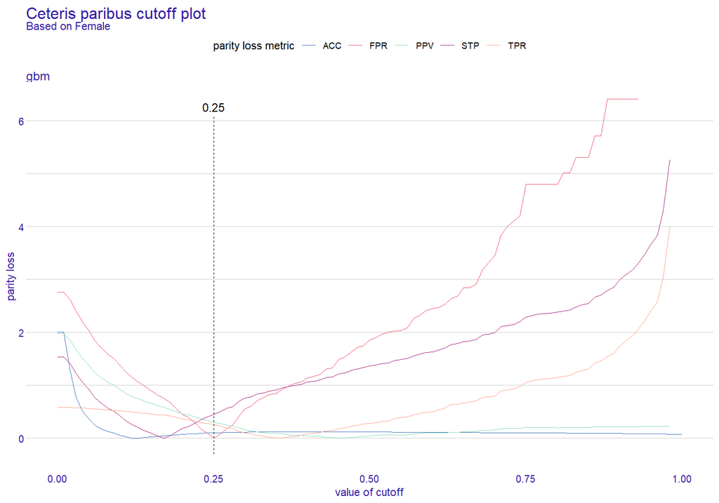

```r
set.seed(1)
gbm_model <-gbm(salary ~. , data = adult, distribution = "bernoulli")
gbm_explainer <- explain(gbm_model,
                         data = adult[,-1],
                         y = adult$salary,
                         verbose = FALSE)

# test fairness object
fobject_test <- fairness_check(gbm_explainer,
                          protected = protected,
                          privileged = "Male",
                          verbose = FALSE)

plot(ceteris_paribus_cutoff(fobject_test, subgroup = "Female"))
```

It is possible to minimize all metrics or only few metrics of our interest.

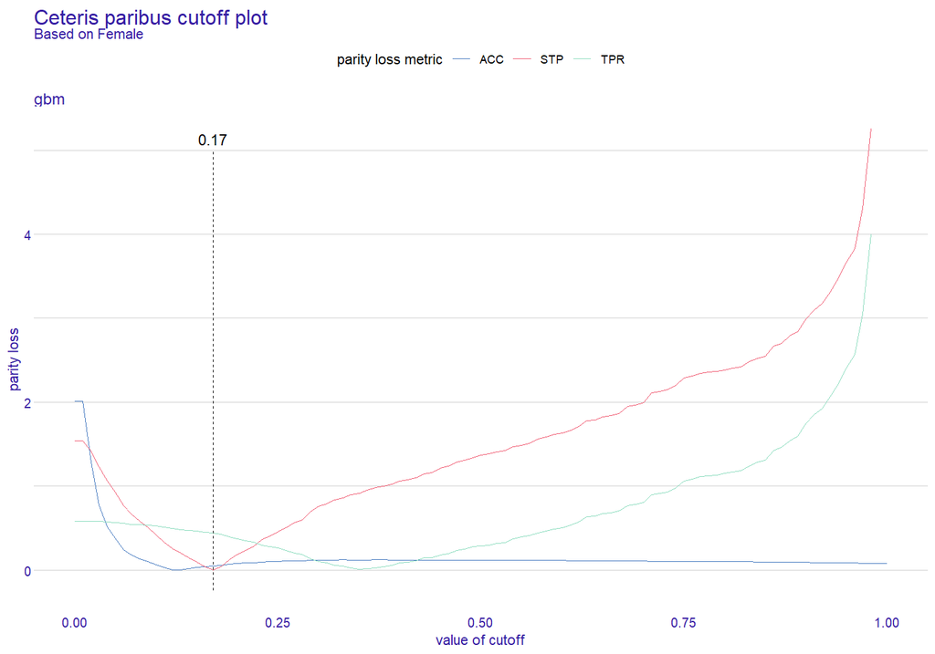

```r
plot(ceteris_paribus_cutoff(fobject_test,
                            subgroup = "Female",
                            fairness_metrics = c("ACC","TPR","STP")))
```

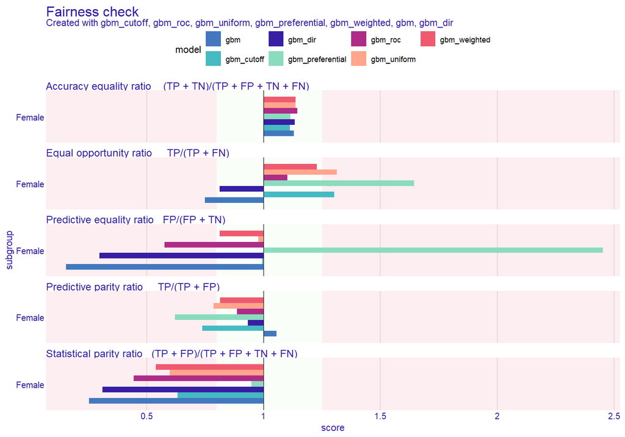

```r
fc <- fairness_check(gbm_explainer, fobject,
                     label = "gbm_cutoff",
                     cutoff = list(Female = 0.25),
                     verbose = FALSE)

plot(fc)
```

```r
print(fc , colorize = FALSE)
```

```
#>
#> Fairness check for models: gbm_cutoff, gbm_roc, gbm_uniform, gbm_preferential, gbm_weighted, gbm, gbm_dir
#>
#> gbm_cutoff passes 2/5 metrics
#> Total loss :  1.052137
#>
#> gbm_roc passes 3/5 metrics
#> Total loss :  1.336648
#>
#> gbm_uniform passes 2/5 metrics
#> Total loss :  1.089414
#>
#> gbm_preferential passes 2/5 metrics
#> Total loss :  2.642933
#>
#> gbm_weighted passes 4/5 metrics
#> Total loss :  1.19968
#>
#> gbm passes 2/5 metrics
#> Total loss :  2.028729
#>
#> gbm_dir passes 3/5 metrics
#> Total loss :  1.777098
```

# 3 Tradeoff between bias and accuracy

There is significant tradeoff between bias and accuracy one way to visualize it is to use `performance_and_fairness` function

```r
paf <- performance_and_fairness(fc, fairness_metric = "STP",
                                 performance_metric = "accuracy")
```

```
#>
#> Creating object with:
#> Fairness metric: STP
#> Performance metric: accuracy
```

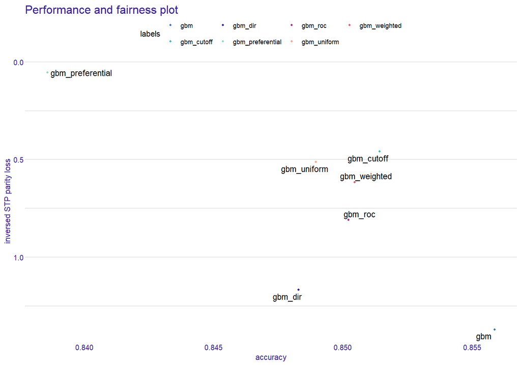

```r
plot(paf)
```

While performing standard model development developers usually split the data into train-test subsets. It is not only possible but advisable to check fairness on a test set. This may be done in following way:

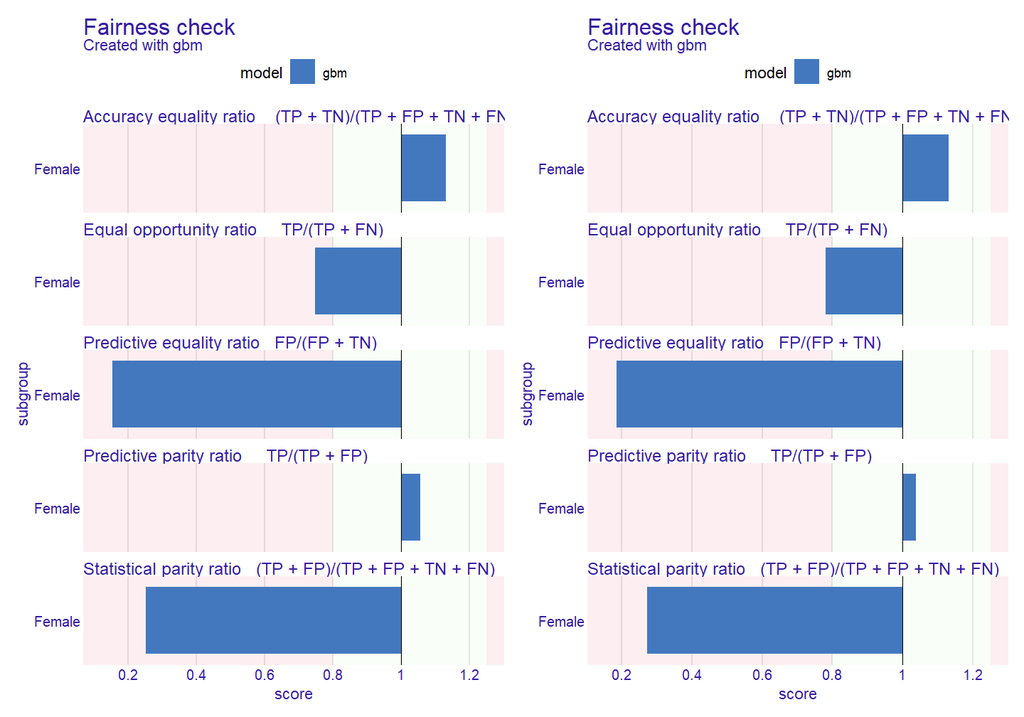

```r
data("adult_test")

adult_test$salary <- as.numeric(adult_test$salary) -1
protected_test <- adult_test$sex

adult_test <- adult_test[colnames(adult_test) != "sex"]


# on test
gbm_explainer_test <- explain(gbm_model,
                              data = adult_test[,-1],
                              y = adult_test$salary,
                              verbose = FALSE)

# the objects are tested on different data, so we cannot compare them on one plot
fobject_train <- fairness_check(gbm_explainer,
                                 protected = protected,
                                 privileged = "Male",
                                 verbose = FALSE)

fobject_test  <- fairness_check(gbm_explainer_test,
                                 protected = protected_test,
                                 privileged = "Male",
                                 verbose = FALSE)

library(patchwork) # with patchwork library we will nicely compare the plots

plot(fobject_train) + plot(fobject_test)
```

# 4 Summary

There is many ways to tackle bias in models. Thanks to `fairmodels` it is easy to compare changes and experiment with new models and bias mitigation techniques. It is also good idea to combine few techniques (for example minimizing once with weights and then with cutoff). `fairness_check` interface is flexible and allows combining models that were trained on different features, encodings etc. Please if you encounter some bug or you have an idea for new feature please write and issue [here](https://github.com/ModelOriented/fairmodels/issues).

# References

Biecek, Przemyslaw. 2018. “DALEX: Explainers for Complex Predictive Models in r.” *Journal of Machine Learning Research* 19 (84): 1–5. https://jmlr.org/papers/v19/18-416.html.

Feldman, Michael, Sorelle A. Friedler, John Moeller, Carlos Scheidegger, and Suresh Venkatasubramanian. 2015. “Certifying and Removing Disparate Impact.” In *Proceedings of the 21th ACM SIGKDD International Conference on Knowledge Discovery and Data Mining*, 259–68. KDD ’15. New York, NY, USA: Association for Computing Machinery. https://doi.org/10.1145/2783258.2783311.

Kamiran, Faisal, and Toon Calders. 2011. “Data Pre-Processing Techniques for Classification Without Discrimination.” *Knowledge and Information Systems* 33 (October). https://doi.org/10.1007/s10115-011-0463-8.

Kamiran, F., A. Karim, and X. Zhang. 2012. “Decision Theory for Discrimination-Aware Classification.” In *2012 IEEE 12th International Conference on Data Mining*, 924–29. https://doi.org/10.1109/ICDM.2012.45.